# Remote Work, Mental Health and Work Satisfaction

Mubashira Qari, Erick Hadi, Marco Castro, Zach Rose, Puja Roy

2025-05-19

**Keywords:** Remote Work, Job Satisfaction, Mental Health, Logistic Regression, Stress

## 1. Introduction

### 1.1 Overview

Remote work, often referred to as telework, work for pay at home or Work From Home (WFH), is a term used to define an arrangement in which employee labor is performed in non-traditional spaces, such as an employee’s home or another public/private space, that are outside of employer’s worksite (i.e. office or job-site) (OPM). Since the early 2000’s, technological innovations and the widespread adoption of high-speed internet have facilitated the growth of remote worker, particular in sectors like technology, marketing, etc. This trend saw rapid adoption in 2020 due to stay-at-home mandates introduced in response to the COVID-19 pandemic. In the United States, for example, the percentage of remote workers grew from 5.7% (9 million) in 2019 to 17.9% in 2019 (BLS, 2024a).

As the covid mortality rates dropped and government mandates were lifted, many employers implemented “return to office” policies that made some or in-person work mandatory (Shimura et al. 2021). These policies were often reflective of negative views on remote work citing poor worker productivity and a belief that workers may be skirting their responsibilities (Toscano et al., 2020). In other cases, workers themselves preferred the office environment and voluntarily returned to onsite work. Estimates from the latest publicly available American Community Survey at writing showed that 13.8% (22 million) of U.S. workers usually worked from home (ACS, 2023), though the number is likely to continue to drop given the current political sentiment.

At the heart of the debate around the effectiveness – or lack thereof – of remote work are the long-term outcomes on the mental health of workers. Prior studies have found both positive and negative outcomes that depend on a multitude of factors, including an individual’s home life, health, work style, and access to support systems to name a few, suggesting the nuanced nature of remote work and its outcomes (Bloom et al., 2015).

Researchers have identified several positive outcomes associated with remote work for employees. These include increased flexibility and autonomy, higher morale and job satisfaction (Tavares, 2017; Shimura et al., 2021). Some remote workers also experienced enhanced productivity, possibly due to a reduction in meetings and other work-related interruptions that eased time pressures through freeing up time for task completion (Weinert et al. 2015). Notably, remote work satisfaction appeared to be higher among employees who reported greater perceived productivity (Toscano & Zappala, 2020).

On a personal level, remote work may facilitate better sharing family responsibilities, as employees save time on commuting, freeing up time to devote to other family obligations such as picking up children from school, household chores, and meal preparation (Darouei & Pluut, 2017). The increased flexibility can lead to an improved work-life balance (Hill et al., 2003; Como, 2021). Further, Shimura et al. (2021) found that remote work significantly decreases psychological and physical stress responses when accounting for confounding factors such as job stressors and sleep quality. Their study found that job stressors, poor sleep, and lack of support systems pose greater risks to productivity than remote work itself.

Job role and industry also seems to play a role in the success of remote work. In 2024, the US Bureau of Labor Statistics found that of the top 10 industries experiencing the highest growth in remote work from 2019–22, 7 had increased output and labor inputs. Outputs far outpaced inputs for the industry sectors of computer systems design and related services; publishing industries, except internet [includes software]; and data processing, internet publishing, and other information services. Beyond increased output, companies saw other gains found in cost savings from lower employee turnover and decreased office space needs (Bloom et al., 2015; BLS 2024a). In their observational experiment of teleworkers in China, Bloom et al. (2015) found that attrition fell by about 50% resulting in lower operating costs from not having to train new employees.

Despite these benefits of remote work, other studies have presented conflicting perspectives. Some researchers argue that there is no clear evidence that remote work enhances productivity (Bailey & Kurland, 2002). Family/life interferences, such as interruptions in childcare, can replace workplace interferences (Grant et al., 2019). In some cases, working from home has been associated with heightened family tensions, particularly in households where both partners work remotely (Douglas et al., 2020). These work-family conflicts and work-life inbalances can negatively affect employee well-being and mental health through increased stress levels (Weinert et al. 2015; Darouei & Pluut, 2017; Como et al. 2021). Como et al. found that some workers “may have trouble setting boundaries and making time for what is important” which may lead to overworking that may result in worker burnout. Smit et al. (2017) conducted a maximum likelyhood analysis of episodic sampling survey controlling for autocorrelation of time where they found that working on-site may be better strategy for boundary management and productivity, as remote workers may experience fatigue from increased transitioning between personal and job roles throughout the day.

Remote work can also lead to increased social isolation ( Di Martino & Wirth, 1990; Weinert et al. 2015; Douglas et al., 2020; Shimura et al., 2021). Psychological impacts of self-isolation have also been observed, with evidence pointing to increased depression and decreased quality of life (Phadnis et al., 2021). In a study focused on the COVID-19 pandemic, Pieh et al. (2020) found that self-isolation significantly contributed to poorer mental health outcomes, especially among women, young adults, and individuals with lower income. This finding was corroborated by Toscano and Zappala through a confirmatory five factor analysis surveying European workers at multiple time points in 2020 during the COVID-19 pandemic.

The evidence on productivity remains mixed, with some studies indicating no clear improvement (Bailey & Kurland, 2002). Other studies found that remote work lead to less team collaboration (Siquiera & Medeiros, 2019; Como, 2021). Even in cases of documented economic benefits and higher output from remote work, gains do not appear to be trickling down into employee incomes (BLS, 2024a). Bloom et al. (2015) also found that career prospects appear to limited among remote workers. Stagnant wages and few opportunities for promotions could contribute to work dissatisfaction among remote workers.

Evidence on worker outcomes further emphasizes the importance of individual differences and organizational context in shaping remote work experiences. Through multiple and ordered logistic regression of survey data, Gorshkova and Lebedeva (2023) found that mental well-being improved by an average of 0.01 units for each additional year of the employees age suggesting that work experience and maturity may contribute to better outcomes for remote workers. Individuals with prior experience working remotely reported better mental health than those for whom remote work was a new experience. Research work conducted during COVID-19 pandemic offered another insight: the importance of personal choice in whether to work remotely or return to the office. Bloom (2015) noted that flexibility and autonomy were critical to satisfaction and effectiveness; alternatives such as hybrid work models could be preferable as they offer a balance between work-life needs and opportunities for team collaboration. Further, Como et al. (2021) and Shimura et al. (2021) suggested that the well-being of remote workers could be improved through greater organizational support, suggesting that structural and managerial factors remain central to successful implementation.

### 1.2. Hypothesis

Given the conflicting results from prior work, this study builds of prior research to explore three outcomes between remote and onsite workers: * job satisfaction; * linkages between perceived isolation and mental health conditions; * and differences in stress levels among genders.

In particular, we aim to test the following hypotheses through statistical analysis.

The literature offers diverging results on remote work satisfaction. While some workers prefer working remotely due to greater flexibility and less daily work-day interruptions, others prefer working onsite (Bloom, 2015). Using self-reported statisfaction responses, we aim to test the following hypothesis.

*Hypothesis 1: Remote workers were more likely to experience dissatisfaction than onsite workers*

The literature indicates that social isolation may contribute to poor mental health (Toscano & Zappala, 2020). Using self-reported ratings for workers’ perception of isolation, we aim to test the following hyphothesis:

*Hypothesis 2: Workers who had a higher perception of worker isolation were more likely to also experience a mental health condition*

The literature indicates differences in stress levels between men and women working remotely, with women facing greater challenges than men. Women may feel a additional work-family conflicts, as they may face greater societal pressures to be the primary caretakers of children, elderly family members, or those requiring additional attention due to illness or similar conditions. Additionally, women may be more likely to be compensated at a lower rate, face greater challenges in career advancement, and face additional pressure to work overtime. Using self-reported stress levels, we aim to test the following hypothesis:

*Hypothesis 3: Female workers experience greater stress levels than male workers.*

## 2. Methodology

### 2.1. Data source

This analysis uses a synthetic dataset downloaded from Kaggle (*Remote Work & Mental Health*). The original dataset is comprised on observations form 5,000 unique employees comprised of employee reported survey data such as level of work satisfaction, work-life balance, and stressors along with their basic employee profile (gender, age, years of experience, and job role) and company assessments (changes in productivity).

### 2.2. Measures

A full list of the measures is included in Appendix A.

### 2.3. Statistical Analysis

For this study, we were interested to understand how remote work affects employee job satisfaction for remote work based on a simulated dataset. Our focus was Satisfaction_with_Remote_Work, and it had two classes: Satisfied and Unsatisfied. Since this is a binary classification problem, our first modeling attempt was logistic regression because it is simple to interpret and can handle binary responses.

Data preparation was conducted before modeling. We removed neutral responders on satisfaction (for a clean contrast between satisfied and dissatisfied groups). Categorical variables were factorized, and a new binary variable Has_Mental_Health_Issue was created from the original Mental_Health_Condition. We also removed non-relevant columns like Productivity_Change and Employee_ID. It was subsequently divided into training and test sets in the ratio of 80/20 to enable proper testing.

## 3. Results

Logistic model output indicated that all but one of the predictor variables were not significant (See Appendix D). Some were weakly or marginally significant at 0.10 or 0.05. The following was seen: Healthcare respondents were significantly more likely to dislike telework (p = 0.039).

Remote workers had moderately increased odds of dissatisfaction compared to onsite workers (p = 0.052), weakly supported Hypothesis 1.

Physical activity last week was on the verge of significance (p = 0.07) and indicates that active players would be sweeter, but that needs to be explored.

Model performing measures were low (See Appendix E & F):

- Accuracy: 50.7%
- Sensitivity ( Identified Unsatisfied): 55.5%
- Specificity ( Identified Satisfied): 45.9%
- AUC Score: ~0.51 (random-like)

This means that the model can’t differentiate between the satisfied and dissatisfied respondents. Poor performance prediction is reflected by the confusion matrix using almost balanced but poor performance — it shows that the data are clean but of poor predictive powers for this specific result.

According to the hypotheses:

Hypothesis 1 is weakly supported: Remote workers were somewhat dissatisfied, although the result is weakly significant.

Hypothesis 2 was not testable since a binary mental health variable had been constructed and the original variable was not present in the model.

## 4. Discussion and Limitations

Though logistic regression indicated what variables might be driving remote work satisfaction, predictive strength was weak, and all but a few variables contributed minimally. The model is suggesting industry-wide dissatisfaction but particularly in health care and less latent regional and behavior-based variations (i.e., exercise, where one works). Overall, thus, the judgment is that remote working job satisfaction is a product of highly interactive, multivariate factors which cannot be fully encompassed within the described characteristics.

Subsequent models might then be supplemented with higher-importance data such as open-ended free text responses, personality traits, work environment control, or organizational support systems in addition to the rating scale.

The research did try to predict employee telecommuting job satisfaction with the use of logistic regression application. Despite having clean, well-formatted data, the model was not discriminative and was about 51% accurate and AUC value was at the near chance level. The predictor variables were extremely poor on statistical significance.

Overall, results suggest that job satisfaction among telecommuters is a multifaceted and intricate phenomenon that cannot be accounted for by underlying conditions of work and demographic variables. Future research must take into account the role played by yet more advanced psychological, social, and organizational variables in efforts to maximize predictive validity as well as understanding. Our dataset also posed a challenge, as no metadata was available was available for many of the parameters in the set. Similarly, we were unable to determine the data collection mechanism and, more importantly, the workers had worked remotely for a similar amount of time. Future work may also benefit from taking a longetudinal approach, whereby workers are ask to self-report at regular intervals after begninning to work remotely to capture possible changes in satisfaction levels.

### References

Ali, W. (2024, September 22). Remote Work & Mental Health. Kaggle. https://www.kaggle.com/datasets/waqi786/remote-work-and-mental-health Dataset

Bertoni, M., Cavapozzi, D., Pasini, G., & Pavese, C. (n.d.). Remote working and mental health during the first wave of the COVID-19 pandemic. *SSRN*. https://doi.org/10.2139/ssrn.4111999

Bloom, N., Liang J., Roberts J., & Ying, Z.J. (2015). Does working from home work? evidence from a Chinese experiment. *The Quarterly Journal of Economics*, 130(1), 165-218. https://www.jstor.org/stable/26372598

Como, R. ., Hambley, L. ., & Domene, J. (2021). An Exploration of Work-Life Wellness and Remote Work During and Beyond COVID-19. *Canadian Journal of Career Development*, 20(1), 46–56. Retrieved from https://cjcd-rcdc.ceric.ca/index.php/cjcd/article/view/92

Darouei, M., & Pluut, H. (2021). Work from home today for a better tomorrow! how working from home influences work‐family conflict and employees’ start of the next workday. *Stress and Health*, 37(5), 986–999. https://doi.org/10.1002/smi.3053

Douglas, M., Katikireddi, M, Taulbut, M., McKee, M., & McCartney G. (2020). Mitigating the wider health effects of COVID-19 panademic response. *BMJ*, 369. https://doi.org/10.1136/bmj.m1557

Gorshkova, M.O., & Lebedeva, P.S. (2023). The impact of transition to a remote work format on the mental health of employees. *Population and Economics*, 7(1), 54-76. https://doi.org/10.3897/popecon.7.e90505

Pieh C., Budimir S., Probst, T. (2020). The effect of age, gender, income, work, and physical activity on mental health during coronavirus disease (COVID-19) lockdown in Austria. *Journal of Psychosomatic Research*, 136, 100-186. https://doi.org/10.1016/j.psychores.2020.110186

Shimura, A., Yokoi, K., Ishibashi, Y., Akatsuka, Y., & Inoue, T. (2021). Remote work decreases psychological and physical stress responses, but full-remote work increases presenteeism. *Frontiers in Psychology*, 12, 730969. https://doi.org/10.3389/fpsyg.2021.730969

Smit, B.W., Maloney, P.W., Maertz, C.P. Jr, & Montag-Smit, T. (2016). Out of sight, out of mind? How and when cognitive role transition episodes influence employee performance. *Human Relations*, 69, 2141-2168. https://doi.org/10.1177/0018726716636204

Toscano, F & Zappala, S. (2020). Social isolation and stress as predictors of productivity perception and remote work satisfaction during the COVID-19 pandemic: The role of concern about the virus in a moderated double mediation. *Sustainability*, 12(23), 9804. https://doi.org/10.3390/su12239804

U.S. Bureau of Labor Statistics (BLS). (2024a). The rise in remote work across industries during the pandemic. U.S. Bureau of Labor Statistics. https://www.bls.gov/opub/btn/volume-13/remote-work-productivity.htm

U.S. Bureau of Labor Statistics (BLS). (2024b, August 29). Civilian labor force participation rate by age, sex, race, and ethnicity. https://www.bls.gov/emp/tables/civilian-labor-force-participation-rate.htm

U.S. Office of Personnel Management (OPM). (n.d.). What is the definition of remote work? Retrieved May 1, 2025, from https://www.opm.gov/frequently-asked-questions/telework-faq/employee/what-is-the-definition-of-remote-work/

Weinert, C., Maier,C., Laumer, S. (2015). “Why are teleworkers stressed? An empirical analysis of the causes of telework-enabled stress” (2015). *Wirtschaftsinformatik Proceedings*, 94, 1407. https://aisel.aisnet.org/wi2015/94

| Variable | Description | Values |
| --- | --- | --- |
| Age | Age of the employee | 22–60 |
| Gender | Gender representation | Female, Male, Non-binary, Prefer not to say |
| Job_Role | Assigned job role | Data Scientist, Designer, HR, Marketing, Project Manager, Sales, Software Engineer |
| Industry | Industry sector or category | Consulting, Education, Finance, Healthcare, IT, Manufacturing, Retail |
| Work_Location | Work setting | Remote, Hybrid, Onsite |
| Hours_Worked_Per_Week | Average weekly hours worked | Numeric value |
| Number_of_Virtual_Meetings | Number of virtual meetings per week | 0–15 |
| Work_Life_Balance_Rating | Self-rated work-life balance | 1–5 |
| Stress_Level | Self-reported stress level | Low, Medium, High |
| Has_Mental_Health_Issue | Derived from Mental_Health_Condition | 1, 0 |
| Access_to_Mental_Health_Resources | Access to mental health resources | Yes / No |
| Social_Isolation_Rating | Perceived social isolation | 1–5 |
| Satisfaction_with_Remote_Work | Satisfaction with remote work | Satisfied, Neutral, Unsatisfied |
| Company_Support_for_Remote_Work | Company’s support for remote work | 1–5 |
| Physical_Activity | Frequency of exercise | Daily, Weekly, None |
| Sleep_Quality | Self-assessed sleep quality | Good, Average, Poor |
| Region | Region of employment | Africa, Asia, Europe, North America, Oceania, South America |

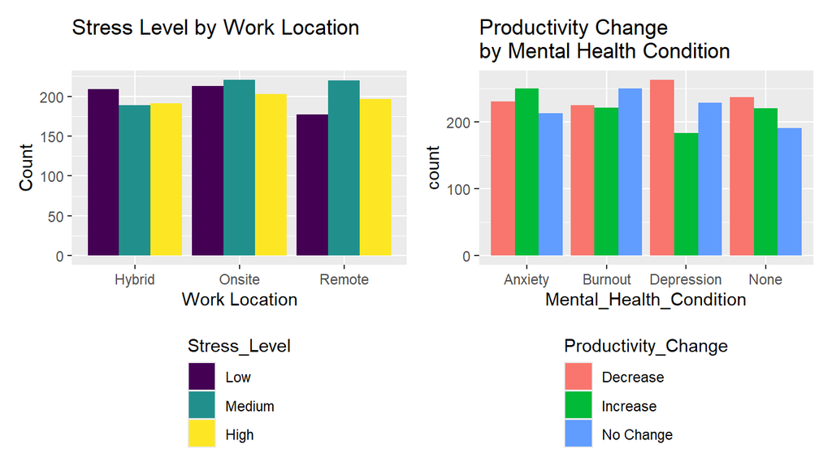

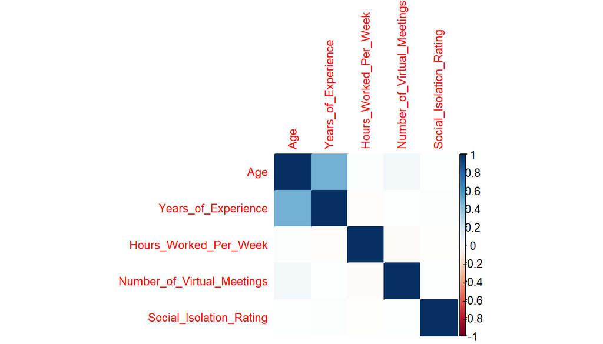

```
## [1] 0.02490357
```

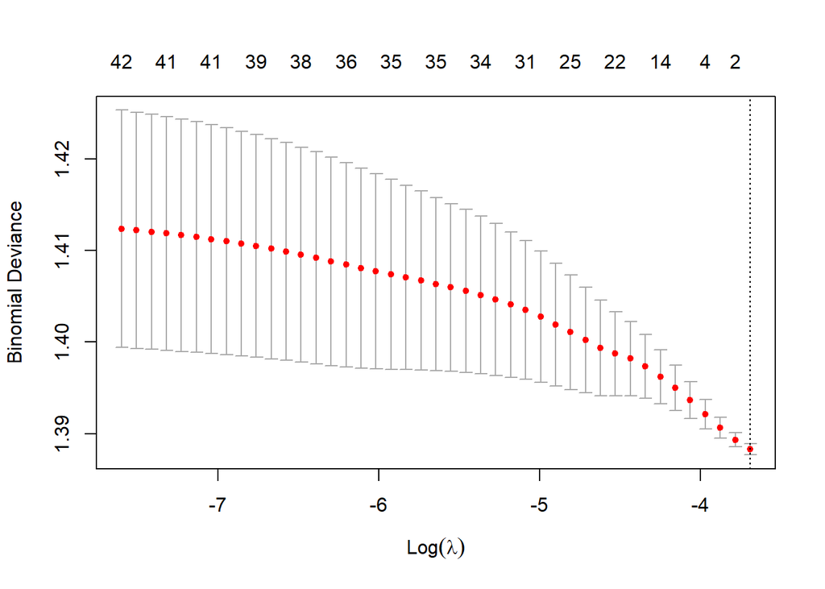

```
##
## Call:
## glm(formula = Satisfaction_with_Remote_Work ~ Age + Gender +
##     Job_Role + Industry + Years_of_Experience + Work_Location +
##     Hours_Worked_Per_Week + Number_of_Virtual_Meetings + Work_Life_Balance_Rating +
##     Stress_Level + Access_to_Mental_Health_Resources + Social_Isolation_Rating +
##     Company_Support_for_Remote_Work + Physical_Activity + Sleep_Quality +
##     Region + Has_Mental_Health_Issue, family = binomial, data = train_data)
##
## Coefficients:
##                                        Estimate Std. Error z value Pr(>|z|)
## (Intercept)                           0.4306632  0.4732162   0.910   0.3628
## Age                                  -0.0006276  0.0069355  -0.090   0.9279
## GenderMale                           -0.1853888  0.1529499  -1.212   0.2255
## GenderNon-binary                     -0.0159591  0.1542091  -0.103   0.9176
## GenderPrefer not to say               0.0072103  0.1546386   0.047   0.9628
## Job_RoleDesigner                     -0.2544863  0.2031265  -1.253   0.2103
## Job_RoleHR                           -0.1990728  0.2006666  -0.992   0.3212
## Job_RoleMarketing                    -0.1291076  0.2045756  -0.631   0.5280
## Job_RoleProject Manager              -0.1324199  0.2055058  -0.644   0.5193
## Job_RoleSales                         0.1930000  0.2062884   0.936   0.3495
## Job_RoleSoftware Engineer             0.2274311  0.2021504   1.125   0.2606
## IndustryEducation                    -0.0965820  0.2017594  -0.479   0.6322
## IndustryFinance                      -0.2446408  0.1978528  -1.236   0.2163
## IndustryHealthcare                   -0.4254039  0.2060353  -2.065   0.0390 *
## IndustryIT                           -0.2943947  0.1936308  -1.520   0.1284
## IndustryManufacturing                -0.3423202  0.2120512  -1.614   0.1065
## IndustryRetail                       -0.3160044  0.2016282  -1.567   0.1171
## Years_of_Experience                   0.0069035  0.0069323   0.996   0.3193
## Work_LocationOnsite                  -0.1668985  0.1317762  -1.267   0.2053
## Work_LocationRemote                  -0.2623313  0.1350497  -1.942   0.0521 .
## Hours_Worked_Per_Week                -0.0052703  0.0045153  -1.167   0.2431
## Number_of_Virtual_Meetings           -0.0052813  0.0114296  -0.462   0.6440
## Work_Life_Balance_Rating.L           -0.1723608  0.1208137  -1.427   0.1537
## Work_Life_Balance_Rating.Q            0.1837839  0.1199199   1.533   0.1254
## Work_Life_Balance_Rating.C            0.1707039  0.1218978   1.400   0.1614
## Work_Life_Balance_Rating^4           -0.1634165  0.1212124  -1.348   0.1776
## Stress_Level.L                       -0.0022854  0.0944975  -0.024   0.9807
## Stress_Level.Q                       -0.0261608  0.0922121  -0.284   0.7766
## Access_to_Mental_Health_ResourcesYes -0.1314379  0.1083477  -1.213   0.2251
```

[output cut: 10 more lines]

```
## RegionEurope                          0.2886673  0.1838994   1.570   0.1165
## RegionNorth America                   0.0716590  0.1937149   0.370   0.7114
## RegionOceania                         0.3649905  0.1893477   1.928   0.0539 .
## RegionSouth America                   0.2096914  0.1879742   1.116   0.2646
## Has_Mental_Health_IssueYes            0.0787498  0.1252072   0.629   0.5294
## ---
## Signif. codes:  0 '***' 0.001 '**' 0.01 '*' 0.05 '.' 0.1 ' ' 1
##
## (Dispersion parameter for binomial family taken to be 1)
##
##     Null deviance: 2019.8  on 1456  degrees of freedom
## Residual deviance: 1971.6  on 1413  degrees of freedom
## AIC: 2059.6
##
## Number of Fisher Scoring iterations: 4
```

```
## Confusion Matrix and Statistics
##
##              Reference
## Prediction    Unsatisfied Satisfied
##   Unsatisfied         101        98
##   Satisfied            81        83
##
##                Accuracy : 0.5069
##                  95% CI : (0.4542, 0.5595)
##     No Information Rate : 0.5014
##     P-Value [Acc > NIR] : 0.4375
##
##                   Kappa : 0.0135
##
##  Mcnemar's Test P-Value : 0.2317
##
##             Sensitivity : 0.5549
##             Specificity : 0.4586
##          Pos Pred Value : 0.5075
##          Neg Pred Value : 0.5061
##              Prevalence : 0.5014
##          Detection Rate : 0.2782
##    Detection Prevalence : 0.5482
##       Balanced Accuracy : 0.5068
##
##        'Positive' Class : Unsatisfied
##
```

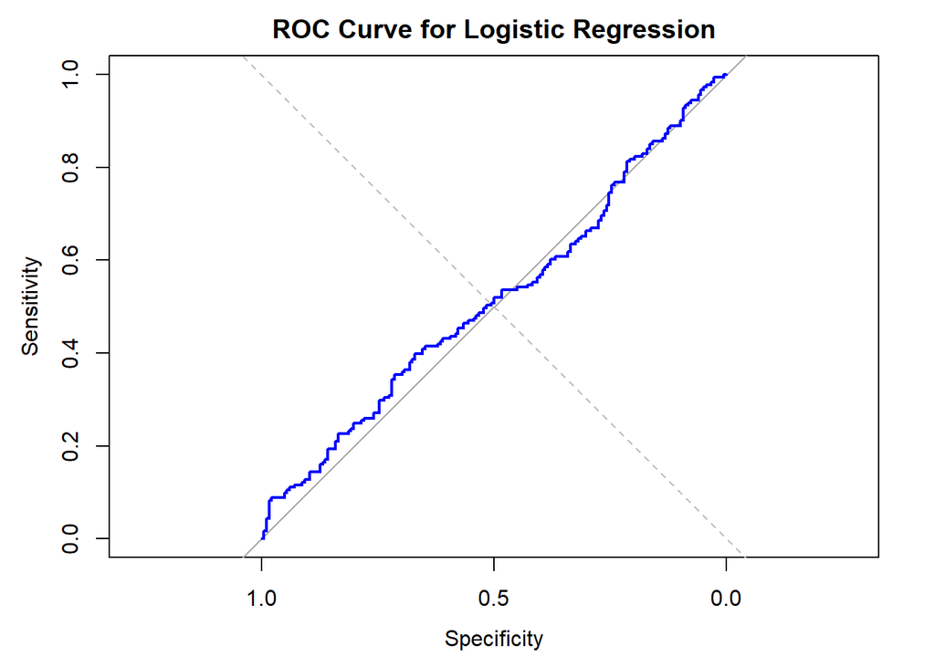